# **Análisis B2B**

#### **Análisis de problemas en ventas**

Problemas en los datasets identificados:

- Formato de fecha `2025.01.16`
- Valores en cero
- Valores negativos (devoluciones/ajustes) --> causa desconocida

#### **Sales Problem Analysis**

Problems identified in the datasets:

- Date format `2025.01.16`
- Zero values
- Negative values (returns/adjustments) --> unknown cause

```python
archivos_ventas = ['ventas_2023', 'ventas_2024', 'ventas_2025']

for archivo in archivos_ventas:
    if archivo in data:
        df = data[archivo]
        print(f"\nAnálisis específico: {archivo}")

        # 1. Verificar formato de fecha
        print(f"\nColumna DÍA - muestra:")
        print(df['Día'].head(3).tolist())

        # 2. Analizar valores en columnas clave
        cols_monetarias = ['Venta Neta ML', 'Venta Neta Unidades',
                          'Venta Neta Kilos', 'Venta Bruta ML', 'Descuento ML']

        print(f"\nAnálisis de columnas monetarias:")
        for col in cols_monetarias:
            if col in df.columns:
                print(f"\n{col}:")

                # Valores cero
                cero_count = (df[col] == 0).sum()
                print(f"- Ceros: {cero_count} ({cero_count/len(df)*100:.2f}%)")

                # Valores negativos
                try:
                    # Intentar convertir a número si es string
                    if df[col].dtype == 'object':
                        valores_num = pd.to_numeric(df[col].astype(str).str.replace(' ', '').str.replace(',', '.'), errors='coerce')
                        neg_count = (valores_num < 0).sum()
                    else:
                        neg_count = (df[col] < 0).sum()
                    print(f"- Negativos: {neg_count} ({neg_count/len(df)*100:.2f}%)")
                except:
                    print(f"- Negativos: No se pudo calcular (formato complejo)")

        # 3. Mostrar ejemplos de valores negativos
        print(f"\n Ejemplos de registros con posibles valores negativos:")
        for col in cols_monetarias[:2]:  # Solo primeras dos para ejemplo
            if col in df.columns:
                muestra = df[df[col].astype(str).str.contains('-', na=False)].head(2)
                if len(muestra) > 0:
                    print(f"\n   {col} (2 ejemplos):")
                    print(muestra[['Día', col] + cols_monetarias[1:3]].head(2))
```

```
Análisis específico: ventas_2023

Columna DÍA - muestra:
['2023.01.02', '2023.01.02', '2023.01.02']

Análisis de columnas monetarias:

Venta Neta ML:
- Ceros: 1290 (4.49%)
- Negativos: 4659 (16.21%)

Venta Neta Unidades:
- Ceros: 6117 (21.28%)
- Negativos: 103 (0.36%)

Venta Neta Kilos:
- Ceros: 6117 (21.28%)
- Negativos: 103 (0.36%)

Venta Bruta ML:
- Ceros: 6035 (20.99%)
- Negativos: 146 (0.51%)

Descuento ML:
- Ceros: 1826 (6.35%)
- Negativos: 373 (1.30%)

 Ejemplos de registros con posibles valores negativos:

   Venta Neta ML (2 ejemplos):
            Día  Venta Neta ML  Venta Neta Unidades  Venta Neta Kilos
481  2023.01.09     -128861.80                -1728            -43.20
578  2023.01.11     -130176.14                 -294            -38.22

   Venta Neta Unidades (2 ejemplos):
            Día  Venta Neta Unidades  Venta Neta Unidades  Venta Neta Kilos
481  2023.01.09                -1728                -1728            -43.20
578  2023.01.11                 -294                 -294            -38.22

Análisis específico: ventas_2024
```

[output cut: 61 more lines]

```
Descuento ML:
- Ceros: 934 (3.53%)
- Negativos: 341 (1.29%)

 Ejemplos de registros con posibles valores negativos:

   Venta Neta ML (2 ejemplos):
           Día  Venta Neta ML  Venta Neta Unidades  Venta Neta Kilos
18  2025.01.17      -22896.00                    0              0.00
19  2025.01.17      -23616.00                    0              0.00

   Venta Neta Unidades (2 ejemplos):
             Día  Venta Neta Unidades  Venta Neta Unidades  Venta Neta Kilos
1063  2025.09.25                  -20                  -20             -8.00
1312  2025.01.03                  -12                  -12             -2.04
```

#### ES **Función de Limpieza de Ventas**

Implementamos toda la lógica definida:

- Limpieza de formato de números
- Conversión de fechas
- Clasificación de transacciones
- Cálculo de variables derivadas

#### US **Sales Cleanup Function**

We implemented all the defined logic:

- Number format cleaning
- Date conversion
- Transaction classification
- Calculation of derived variables

```python
def limpiar_valor_monetario(valor):
    """
    Limpia un valor monetario con formato como "48 000,00" o "-48 000,00"
    """
    if pd.isna(valor):
        return np.nan

    s = str(valor).strip()

    if s == '' or s == 'nan':
        return np.nan

    if s in ['#N/D', '#REF!', 'N/A']:
        return np.nan

    s = s.replace(' ', '')
    s = s.replace(',', '.')

    if s == '-':
        return np.nan

    try:
        return float(s)
    except:
        return np.nan


def limpiar_fecha(dia_valor):
    """
    Convierte formato "2025.01.16" a datetime
    """
    if pd.isna(dia_valor):
        return np.nan

    s = str(dia_valor).strip()

    if isinstance(dia_valor, pd.Timestamp):
        return dia_valor

    try:
        return pd.to_datetime(s, format='%Y.%m.%d', errors='coerce')
    except:
        try:
            return pd.to_datetime(s, errors='coerce')
        except:
            return np.nan


def clasificar_transaccion(row):
    """
    Clasifica el tipo de transacción según unidades y valor monario
    """
    unidades = row.get('VENTA_NETA_UNIDADES', 0)
    ml = row.get('VENTA_NETA_ML', 0)

    if pd.isna(unidades) or pd.isna(ml):
        return 'DESCONOCIDO'

    # Casos inconsistentes (unidades positivas con ML negativo)
    if unidades > 0 and ml < 0:
        return 'AJUSTE'
    # Unidades negativas con ML positivo (también inconsistente)
    if unidades < 0 and ml > 0:
        return 'AJUSTE'
    if unidades > 0:
        return 'VENTA'
    elif unidades < 0:
        return 'DEVOLUCION'
    elif unidades == 0 and ml != 0:
        return 'AJUSTE'
    elif unidades == 0 and ml == 0:
        return 'NULO'
    else:
        return 'DESCONOCIDO'


def limpiar_ventas(df, año):
    """
    Función principal de limpieza para archivos de ventas
    """
    print(f"Limpiando datos: {año}")

    df_clean = df.copy()

    # 1. Estandarizar nombres de columnas
    print("Paso 1: Nombres de columnas:")
    columnas_originales = df_clean.columns.tolist()
    print(f"   Columnas originales: {columnas_originales[:5]}... (total: {len(columnas_originales)})")

    df_clean.columns = [str(col).upper().strip().replace(' ', '_') for col in df_clean.columns]
    print(f"Columnas estandarizadas: {len(df_clean.columns)}")

    # 2. Limpiar columna DÍA
    print("\nPaso 2: Fechas")

    # Buscar columna de fecha (podría ser 'DÍA' o 'DIA' o 'FECHA')
    posibles_fechas = [col for col in df_clean.columns if 'DIA' in col or 'FECHA' in col]
    print(f"   Columnas de fecha encontradas: {posibles_fechas}")

    if 'DÍA' in df_clean.columns:
        col_fecha = 'DÍA'
    elif 'DIA' in df_clean.columns:
        col_fecha = 'DIA'
    elif len(posibles_fechas) > 0:
        col_fecha = posibles_fechas[0]
    else:
        print("No se encontró columna de fecha")
        return None

    print(f"   Usando columna: '{col_fecha}'")
    print(f"   Muestra de valores: {df_clean[col_fecha].head(3).tolist()}")

    df_clean['FECHA'] = df_clean[col_fecha].apply(limpiar_fecha)

    # Eliminar filas con fecha inválida
    fechas_invalidas = df_clean['FECHA'].isna().sum()
    if fechas_invalidas > 0:
        print(f"     {fechas_invalidas} fechas inválidas encontradas")
        df_clean = df_clean.dropna(subset=['FECHA'])
        print(f"- Se eliminaron {fechas_invalidas} filas con fecha inválida")
    else:
        print(f"- Todas las fechas son válidas")

    # 3. Columnas monetarias a limpiar
    print("\nPaso 3: Valores monetarios")
    cols_monetarias = ['VENTA_NETA_ML', 'VENTA_NETA_UNIDADES',
                       'VENTA_NETA_KILOS', 'VENTA_BRUTA_ML', 'DESCUENTO_ML']

    for col in cols_monetarias:
        if col in df_clean.columns:
            print(f"   Procesando: {col}")
            valores_originales = df_clean[col].copy()

            # Mostrar ejemplo antes
            ejemplo_antes = df_clean[col].dropna().head(2).tolist()
            print(f"      Ejemplo antes: {ejemplo_antes}")

            df_clean[col] = df_clean[col].apply(limpiar_valor_monetario)

            # Mostrar ejemplo después
            ejemplo_despues = df_clean[col].dropna().head(2).tolist()
            print(f"      Ejemplo después: {ejemplo_despues}")

            cambios = (valores_originales.notna() & df_clean[col].isna()).sum()
            if cambios > 0:
                print(f" {cambios} valores no convertibles (se hicieron NaN)")
            else:
                print(f"{cambios} valores no convertibles")
        else:
            print(f"Columna no encontrada: {col}")

    # 4. Clasificar transacciones
    print("\nPaso 4: Clasificacion transacciones")
    df_clean['TIPO_TRANSACCION'] = df_clean.apply(clasificar_transaccion, axis=1)

    tipos = df_clean['TIPO_TRANSACCION'].value_counts()
    print(f"   Distribución de tipos:")
    for tipo, count in tipos.items():
        print(f"      {tipo}: {count} ({count/len(df_clean)*100:.1f}%)")

    # 5. Calcular variables derivadas
    print("\n Paso 5: Variables derivadas")

    # Precio unitario
    mask_precio = (df_clean['VENTA_NETA_UNIDADES'] > 0) & (df_clean['VENTA_NETA_ML'] > 0) & (df_clean['VENTA_NETA_ML'].notna())
    df_clean['PRECIO_UNITARIO'] = np.nan
    df_clean.loc[mask_precio, 'PRECIO_UNITARIO'] = (
        df_clean.loc[mask_precio, 'VENTA_NETA_ML'] / df_clean.loc[mask_precio, 'VENTA_NETA_UNIDADES']
    )
    print(f"   Precio unitario calculado para {mask_precio.sum():,} registros")

    # Porcentaje de descuento
    mask_dto = (df_clean['VENTA_BRUTA_ML'] > 0) & (df_clean['VENTA_NETA_ML'].notna())
    df_clean['PCT_DESCUENTO'] = np.nan
    df_clean.loc[mask_dto, 'PCT_DESCUENTO'] = (
        (df_clean.loc[mask_dto, 'VENTA_BRUTA_ML'] - df_clean.loc[mask_dto, 'VENTA_NETA_ML']) /
        df_clean.loc[mask_dto, 'VENTA_BRUTA_ML'] * 100
    )
    print(f"   Porcentaje de descuento calculado para {mask_dto.sum():,} registros")

    # 6. Variables de tiempo
    print("\nPaso 6: Agregando variables de tiempo")
    df_clean['AÑO'] = año
    df_clean['MES'] = df_clean['FECHA'].dt.month
    df_clean['SEMANA'] = df_clean['FECHA'].dt.isocalendar().week
    df_clean['DIA_SEMANA'] = df_clean['FECHA'].dt.dayofweek
    df_clean['QUINCENA'] = df_clean['FECHA'].dt.day.apply(lambda x: 1 if x <= 15 else 2)
    print(f"Variables agregadas: AÑO, MES, SEMANA, DIA_SEMANA, QUINCENA")

    # 7. Eliminar filas NULO
    print("\nPaso 7: Eliminar filas tipo NULO")
    nulos_antes = len(df_clean)
    df_clean = df_clean[df_clean['TIPO_TRANSACCION'] != 'NULO']
    eliminados = nulos_antes - len(df_clean)
    print(f"   Se eliminaron {eliminados} filas tipo NULO")

    return df_clean
```

#### **Limpieza de Archivos de Ventas**

**ES** *Aplicamos la función a 2023, 2024 y 2025*

**US** *We applied the function to 2023, 2024, and 2025*

```python
ventas_limpias = {}

for archivo in archivos_ventas:
    if archivo in data:
        año = archivo.split('_')[1]
        ventas_limpias[año] = limpiar_ventas(data[archivo], año)


for año, df in ventas_limpias.items():
    print(f"\n{año}:")
    print(f"   Registros: {len(df):,}")
    print(f"   Rango fechas: {df['FECHA'].min().date()} a {df['FECHA'].max().date()}")
    print(f"   Productos únicos: {df['CODIGO_MATERIAL'].nunique():,}")

    # Ventas totales
    ventas_totales = df[df['TIPO_TRANSACCION'] == 'VENTA']['VENTA_NETA_ML'].sum()
    devoluciones = df[df['TIPO_TRANSACCION'] == 'DEVOLUCION']['VENTA_NETA_ML'].sum()
    print(f"   Ventas netas (solo VENTA): {ventas_totales:,.0f} ML")
    print(f"   Devoluciones: {devoluciones:,.0f} ML")
    print(f"   Neto total (incluye ajustes): {df['VENTA_NETA_ML'].sum():,.0f} ML")
```

```
Limpiando datos: 2023
Paso 1: Nombres de columnas:
   Columnas originales: ['Año', 'Mes Nombre', 'Mes Número', 'Día', 'Nombre Cliente']... (total: 16)
Columnas estandarizadas: 16

Paso 2: Fechas
   Columnas de fecha encontradas: []
   Usando columna: 'DÍA'
   Muestra de valores: ['2023.01.02', '2023.01.02', '2023.01.02']
- Todas las fechas son válidas

Paso 3: Valores monetarios
   Procesando: VENTA_NETA_ML
      Ejemplo antes: [106042.51999999999, 113304.048]
      Ejemplo después: [106042.51999999999, 113304.048]
0 valores no convertibles
   Procesando: VENTA_NETA_UNIDADES
      Ejemplo antes: [72, 330]
      Ejemplo después: [72.0, 330.0]
0 valores no convertibles
   Procesando: VENTA_NETA_KILOS
      Ejemplo antes: [33.696, 44.55]
      Ejemplo después: [33.696, 44.55]
0 valores no convertibles
   Procesando: VENTA_BRUTA_ML
      Ejemplo antes: [109209.6, 116688.0]
      Ejemplo después: [109209.6, 116688.0]
0 valores no convertibles
   Procesando: DESCUENTO_ML
      Ejemplo antes: [3167.08, 3383.9519999999998]
      Ejemplo después: [3167.08, 3383.9519999999998]
0 valores no convertibles

Paso 4: Clasificacion transacciones
   Distribución de tipos:
      VENTA: 22527 (78.4%)
      AJUSTE: 4827 (16.8%)
      NULO: 1290 (4.5%)
      DEVOLUCION: 103 (0.4%)

```

[output cut: 116 more lines]

```
2024:
   Registros: 27,429
   Rango fechas: 2024-01-03 a 2024-12-31
   Productos únicos: 541
   Ventas netas (solo VENTA): 25,383,703,818 ML
   Devoluciones: -298,648,278 ML
   Neto total (incluye ajustes): 23,482,778,996 ML

2025:
   Registros: 25,573
   Rango fechas: 2025-01-03 a 2025-12-05
   Productos únicos: 484
   Ventas netas (solo VENTA): 22,369,551,600 ML
   Devoluciones: -145,201,029 ML
   Neto total (incluye ajustes): 20,498,569,978 ML
```

```python
df_ventas_total = pd.concat(ventas_limpias.values(), ignore_index=True)

print(f"\nDataset unificado: {len(df_ventas_total):,} filas x {len(df_ventas_total.columns)} columnas")
print(f"Período: {df_ventas_total['FECHA'].min().date()} a {df_ventas_total['FECHA'].max().date()}")
```

```
Dataset unificado: 80,459 filas x 24 columnas
Período: 2023-01-02 a 2025-12-05
```

#### **Visualización Exploratoria**

#### **Análisis de jerarquía por producto**

```python
df_analisis = df_ventas_total[df_ventas_total['TIPO_TRANSACCION'] == 'VENTA'].copy()

# Verificar columnas disponibles
columnas_jerarquia = ['SECTOR_CATEGORITA', 'SECTOR', 'CATEGORÍA', 'MARCA', 'SUB_MARCA']
print("\nColumnas de jerarquia encontradas:")
for col in columnas_jerarquia:
    if col in df_analisis.columns:
        print(f"  - {col}")
    else:
        print(f"  - {col} (NO ENCONTRADA)")
```

```
Columnas de jerarquia encontradas:
  - SECTOR_CATEGORITA
  - SECTOR
  - CATEGORÍA
  - MARCA
  - SUB_MARCA
```

#### **Ventas por sector**

```
Top sectores por ventas:
  Galletas                            | 56,315,490,490 ML |  77.6%
  Chocolates                          | 11,354,010,446 ML |  15.6%
  TMLUC                               | 3,046,608,059 ML |   4.2%
  Café                                | 1,034,677,744 ML |   1.4%
  Nutrición Experta                   |  366,950,979 ML |   0.5%
```

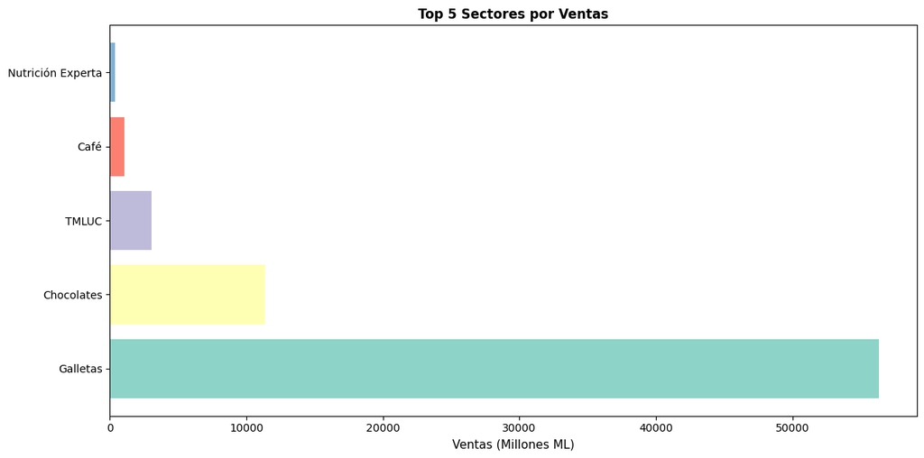

```python
if 'SECTOR' in df_analisis.columns:
    sector_ventas = df_analisis.groupby('SECTOR')['VENTA_NETA_ML'].sum().sort_values(ascending=False)

    print("\nTop sectores por ventas:")
    for sector, ventas in sector_ventas.head(5).items():
        pct = ventas / sector_ventas.sum() * 100
        print(f"  {sector:<35} | {ventas:12,.0f} ML | {pct:5.1f}%")

    # Grafico
    fig, ax = plt.subplots(figsize=(12, 6))
    colores = plt.cm.Set3(range(len(sector_ventas.head(5))))
    ax.barh(sector_ventas.head(5).index, sector_ventas.head(5).values / 1e6, color=colores)
    ax.set_xlabel('Ventas (Millones ML)', fontsize=11)
    ax.set_title('Top 5 Sectores por Ventas', fontsize=12, fontweight='bold')
    plt.tight_layout()
    plt.show()
```